# Scraping dynamic websites & regular expressions

11/19/2019

## Web scarping dynamic websites

## Problems from the previous class

We tried:

- scrape prices from “Search” page: a character vector of `"-"`s
- scrape names, rating, and prices from “Explore” page: an empty character vector `character(0)`

In other words, both of them returned no content.

## Under the hood

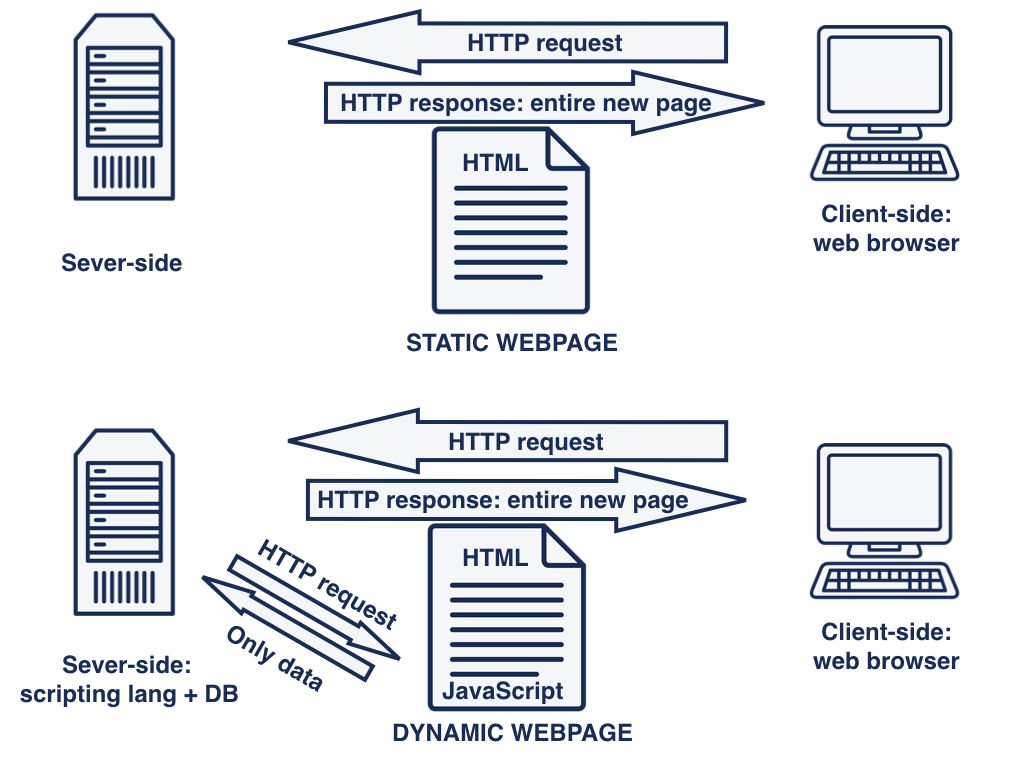

## Static vs dynamic web-pages

Static approach:

- The entire web-page (including all of its content and data) is generated on the server-side, and then fetched all at once by the client.
- The client can get the next piece of data by loading a new page (e.g., the next page).
- The page is static object, it does not interact with the server anymore.

## Static vs dynamic web-pages

Dynamic approach:

- The web-page (the structure) is again generated on the server side, but the data is loaded “on demand” as a response to user actions (by calling JavaScript).
- The client can get the next piece of data by, for instance, by scrolling down.
- The page is not self-contained and static anymore. The elements are created and modified dynamically (as result of execution of JavaScript code).

## Approaches for Scraping data from Dynamic Websites

- Reverse engineering JavaScript: sending AJAX requests manually (sometimes JS code can be machine-generated, e.g., Google Web Toolkit)
- **Rendering JavaScript**

The latter workaround emulates the browser rendering that is parsing HTML, applying the CSS formatting and executing JavaScript to display a web page. In other words, we will simulate user actions.

## Tools / requirements

- Docker: an isolated collection of required libraries (and other dependencies) to run your application. It is like an artificial environment or a virtual machine on which we run Selenium.
- Selenium: a framework that allows automating web-browser actions. Selenium controls actions of our headless browser.
- (Headless) Chrome or Firefox: a web browser without a graphical user interface (GUI). Headless browsers provide automated control of a web page in an environment similar to popular web browsers, but are executed via a command-line interface or using network communication.
- `RSelenium`: the package to control Selenium via R (rather than via command line).
- R

## Tools / requirements

[figure not shown]

## Workflow

1. Start Docker (open Docker app on macOS)
2. Run Docker container of the selenium chrome browser

   ```bash
   docker run -d -p 4445:4444 selenium/standalone-chrome
   ```

   It is possbile to check oneself running `docker ps` that would yield the current running containers.
3. Load the `RSelenium` package

   ```r
   library(RSelenium)
   ```

4. Connect to a running server

   ```r
   remDr <- remoteDriver(remoteServerAddr = "localhost", port = 4445L,
                         browserName = "chrome")
   ```

## Workflow

The last item generates a new object of the `remoteDriver` class. Objects of this class have dozens of methods that can be found by `?remoteDriver`. We cover only the most used ones:

- `$open()`: instantiates (open) the browser
- `$navigate(url)`: navigates the browser to a given url
- `$screenshot(display = TRUE)`: takes a screenshot of the current page
- `$findElement()`: searches for an element on the page and returns it (class `webElement`)
  - `$clickElement()`: clicks the element
  - `$sendKeysToElement(list(key = "end"))`: scrolls down
- `$getPageSource()`: returns the current page source
- `$quit()`: deletes the session & closes open browsers

## Use case with wine

## Exercise

## Regular expressions (regex)

## Introduction

A regular expression (regex for short) is a set of characters that specify a pattern.

Two types of regular expressions engines are used in R (difference in metacharacters):

- POSIX extended regular expressions (actually, it is modified version of Ville Laurikari’s TRE engine, the default one)
- Perl-like regular expressions

It is simple to search for a specific word or string of characters. Almost every editor on every computer system can do this. Regular expressions are more powerful and flexible:

- words of a certain size
- words with four or more vowels that end with an “s”
- replace punctuation by underscore, etc.

## Introduction

[figure not shown]

## Tools

- base R: `grep`, `grepl`, `regexpr`, `gregexpr`, `sub`, `gsub`, and `strsplit`. Not really intuitive names unless you are a hardcore Linux fan.
- `stringi` package: build on top of `icu4c` C/C++ library, comprehensive and exhaustive set of functions and tools (244 functions)
- `stringr` package: a `stringi` wrapper, a part of `tidyverse`, most commonly used 49 hand-picked functions with self-explanatory names that starts with `str` (i.e., `str_length()`)

## `stringr`

- `stringr` convention of naming: functions start with `str_` prefix
- coherent order of arguments: easier to use in conjunction with `lapply()` and `%>%`
- well-designed output of functions, e.g., the result of one function can be substituted as argument to the other

Installing and loading `stringr`:

```r
install.packages("stringr")
library(stringr)
```

## String basics

One can create strings with either single quotes `'` or double quotes `"`. It is possible to use `'` inside `""`, and vice versa:

```r
"This is a string."
```

```
## [1] "This is a string."
```

```r
"This is a string with '"
```

```
## [1] "This is a string with '"
```

```r
'One more string, but this time with "'
```

```
## [1] "One more string, but this time with \""
```

## Escape character `\` (backslash)

From the last slide you probably spotted `\` character in the last string before `"`. It is called an escape character. It allows specifying special characters or, in other words, “escaping”. E.g., specify `"` using double quotes `""` and specify `'` using sible quote `''`:

```r
 "\"" # or '"'
```

```
## [1] "\""
```

```r
'\'' # or "'"
```

```
## [1] "'"
```

## Printed representation

Beware that the printed representation of a string is not the same as string itself, because the printed representation shows the escapes. To see the raw contents of the string, use `writeLines()` or `cat()`:

```r
x <- "\""
x # which is equialent to print(x)
```

```
## [1] "\""
```

```r
writeLines(x)
```

```
## "
```

```r
cat(x)
```

```
## "
```

## Other special characters

To use backslash, one specifies double backslash `\\`:

```r
"\\"
```

```
## [1] "\\"
```

Common special characters:

```r
"\n" # new line
"\t" # tab character
```

Unicode character with given hex code:

```r
"\u{00B5}"
```

```
## [1] "µ"
```

## Useful functions from `stringr`

- `str_length()`: equivalent of `nchar()` and **not** `length()`

  ```r
  str_length(c("aaa", "bbbbb", "zz"))
  ```

  ```
  ## [1] 3 5 2
  ```

- `str_c()`: equivalent of `paste()`

  ```r
  str_c(c("a", "b"), "c", sep = ", ", collapse = "")
  ```

  ```
  ## [1] "a, cb, c"
  ```

- `str_sub()`: equivalent of `substr()`

  ```r
  str_sub(c("some", "characters"), 1, 3)
  ```

  ```
  ## [1] "som" "cha"
  ```

## Matching patterns with regular expressions

Again, regex is a language in its own right created to match patterns in strings.

We first learn how to compose regexes, that is how to describe the pattern. We use the function `str_view(string, pattern)` to highlight the `pattern` in `string`s in Viewer. The function `str_view()` highlights only the first match, while `str_view_all()` highlights all of them.

There is also a nice RStudio Addin for regex with interactive interface. To install it use:

```r
devtools::install_github("gadenbuie/regexplain")
```

## Basic matches

```r
x <- c("black", "blue", "brown")
str_view(x, "bla")
```

[interactive chart not shown]

## Basic matches: metacharacter `.`

The metacharacter `.` matches any characters except a new line:

```r
str_view(c("black", "blue", "brown"), "bl.")
```

[interactive chart not shown]

## Basic matches: metacharacter `.`

To match literal `.` in the string. One need to use an “escape” symbol `\` (the same as in strings) to tell the regular expression you want to match it exactly, not use its special behavior. Regexes are represented by strings, for which `\` is also the escape symbol. Therefore, to create the regular expression `\.` we need the string `"\\."`.

```r
writeLines("\\.")
```

```
## \.
```

```r
str_view(c("abc", "a.c", "bef"), "a\\.c")
```

[interactive chart not shown]

## Basic matches

Further, if you want to match a literal `\`, one needs to escape it by creating regex `\\`. Each of the `\` in the regex should represented by two `\` in the string, and therefore, to match one backslash `\` we need to use `"\\\\"`.

```r
x <- "a\\b"
writeLines(x)
```

```
## a\b
```

```r
str_view(x, "\\\\")
```

[interactive chart not shown]

## Anchors ⚓

By default, regular expressions will match any part of a string. It is possible to match the pattern at the start or at the end of the string by using *anchors*:

## Anchors ⚓

- `^` means **the start** of the string

  ```r
  str_view(c("shirt", "hoodie", "t-shirt"), "^sh")
  ```

[interactive chart not shown]

- `$` means **the end** of the string

  ```r
  str_view(c("shirt", "hoodie", "t-shirt"), "rt$")
  ```

[interactive chart not shown]

## Character classes

The metacatacter `.` matches any character (except a new line). What about, for example, only digits or alphabetic characters? There are a number of predefined classes in R. For example:

- digits `\d` (do not forget to “escape”) or `[[:digit:]]`

  ```r
  str_view_all(c("132blabla", "hop 43"), "\\d")
  ```

[interactive chart not shown]

- punctuation characters `[[:punct:]]`

  ```r
  str_view_all(c("33", "hop.43!"), "[[:punct:]]")
  ```

[interactive chart not shown]

## Character classes

- upper-case letters

  ```r
  str_view_all(c("This is", "a sentence YEAH"), "[[:upper:]]")
  ```

[interactive chart not shown]

Please see a comprehensive list in the regex cheat sheet (see in references).

## Character classes

One can also specify a list of characters that should be matched between `[` and `]`:

```r
str_view(c("rmd", "rwd", "r.d", "rkc"), "r[mw]d")
```

[interactive chart not shown]

Further, it is possible to match “anything except” by using `^`:

```r
str_view_all("aerg12wegcwef34._ ", "[^13_]")
```

[interactive chart not shown]

## Character classes

Metacharacters inside character classes (i.e., between `[` and `]`) have literal meaning:

```r
str_view(c("a.c", "abc", "a.k"), "a[.].")
```

[interactive chart not shown]

This can be used as an alternative to the backslash escaping symbol: it works for `$`, `.`, `|`, `?`, `*`, `+`, `(`, `)`, `[`, and `{`, but not for `]`, `\`, `^`, and `-`.

## Alternation

```r
str_view(c("grey", "gray"), "gr(e|a)y")
```

[interactive chart not shown]

```r
str_view(c("color", "colour"), "col(o|)r")
```

[interactive chart not shown]

## Repetition

To control the number of repetitions of the match, the following metacaracters are used:

- `?`: zero or one times

  ```r
  str_view_all("I scream aaaaa and aaa", "aa?")
  ```

[interactive chart not shown]

- `+`: one or more times

  ```r
  str_view_all("I scream aaaaa and aaa", "aa+")
  ```

[interactive chart not shown]

- `*`: zero or more times

  ```r
  str_view_all("I scream aaaaa and aaa", "aa*")
  ```

[interactive chart not shown]

## Repetition

Specify the exact number of matches:

- `{n}`: exactly n times
- `{n,}`: n times or more
- `{,m}`: at most m times
- `{n,m}`: between n and m times

```r
str_view_all("AA BB A BBBB AAAAA BB AAA BBBBB AA AAAAAAA", "A{4,5}")
```

[interactive chart not shown]

## Grouping and backreferences

You can refer to the same text as previously matched by a capturing group with backreferences, like `\1`, `\2` etc. For example, the following regular expression finds all fruits that have a repeated pair of letters.

```r
str_view(fruit, "(..)\\1", match = TRUE)
```

[interactive chart not shown]

## Tools

Various functions from `stringr` allows us to:

- Determine whether strings contain a pattern
- Find the positions of matches
- Extract the content of matches
- Replace matches with new values
- Split a string based on a match

## `stringr::str_detect()` and `stringr::str_count()`

```r
bands <- c("Green Day", "The Offspring", "Blink-182", "Sum 41")
str_detect(bands, "\\d")
```

```
## [1] FALSE FALSE  TRUE  TRUE
```

```r
str_count(bands, "\\d")
```

```
## [1] 0 0 3 2
```

## `stringr::str_extract()`

```r
price_sentences <- c("This one contains price of 324.21 and 4.25.",
                     "The price of the pizza is 25.1",
                     "The Moretti beer costs around 7 francs.")
str_extract(price_sentences, "(\\d{1,}\\.\\d{1,}|\\d{1,})")
```

```
## [1] "324.21" "25.1"   "7"
```

```r
str_extract_all(price_sentences, "(\\d{1,}\\.\\d{1,}|\\d{1,})")
```

```
## [[1]]
## [1] "324.21" "4.25"
##
## [[2]]
## [1] "25.1"
##
## [[3]]
## [1] "7"
```

## `stringr::str_replace()`

```r
messy_strings <- c("\n CHF 23 \n", "\n CHF 14 \n", "\n CHF 67 \n")
str_replace_all(messy_strings, "(\\s|CHF)", "")
```

```
## [1] "23" "14" "67"
```

## `stringr::str_split()`

```r
seventies <- "Led Zeppelin|Deep Purple|Black Sabbath"
str_split(seventies, "\\|")
```

```
## [[1]]
## [1] "Led Zeppelin"  "Deep Purple"   "Black Sabbath"
```

```r
fruits_sentence <- "apples, pears, and bananas"
str_split(fruits_sentence, "(, and |, )")
```

```
## [[1]]
## [1] "apples"  "pears"   "bananas"
```

## Outro

> “When you first look at a regexp, you’ll think a cat walked across your keyboard, but as your understanding improves they will soon start to make sense.”

[figure not shown]

## References (web scraping)

- [Web Design Choices](https://www.spiderwriting.co.uk/static-dynamic.php)
- [Python Web Scraping - Dynamic Websites](https://www.tutorialspoint.com/python_web_scraping/python_web_scraping_dynamic_websites.htm)
- [Using RSelenium and Docker To Webscrape In R - Using The WHO Snake Database](https://callumgwtaylor.github.io/blog/2018/02/01/using-rselenium-and-docker-to-webscrape-in-r-using-the-who-snake-database/)
- [RSelenium Tutorial: A Tutorial to Basic Web Scraping With RSelenium](https://thatdatatho.com/2019/01/22/tutorial-web-scraping-rselenium/)
- [Web Scraping Google Sheets with RSelenium](https://www.r-bloggers.com/web-scraping-google-sheets-with-rselenium/)
- [RSelenium Docker](https://rpubs.com/johndharrison/RSelenium-Docker)
- [How to Use Selenium and Docker to Scrape and Test Websites](https://towardsdatascience.com/an-introduction-to-web-browser-automation-with-selenium-and-docker-containers-c1bcbcb91540)
- [Web Scraping Javascript Content](https://www.r-bloggers.com/web-scraping-javascript-content/)

## References (regex)

- [Regular Expressions as used in R](https://stat.ethz.ch/R-manual/R-devel/library/base/html/regex.html)
- [Regular expressions](https://stringr.tidyverse.org/articles/regular-expressions.html)
- [A Brief Comparison of stringi and stringr](https://rud.is/b/2017/02/06/strung-out-on-string-ops-a-brief-comparison-of-stringi-and-stringr/)
- [stringi: reference manual](https://cran.r-project.org/web/packages/stringi/stringi.pdf)
- [From base R](https://stringr.tidyverse.org/articles/from-base.html)
- [Regular Expressions](http://www.grymoire.com/Unix/Regular.html)
- [Regex cheet sheet](https://rstudio.com/wp-content/uploads/2016/09/RegExCheatsheet.pdf)
- [Escape character](https://en.wikipedia.org/wiki/Escape_character)
- [RegExplain RStudio addin](https://www.garrickadenbuie.com/project/regexplain/)
- [Regular Expressions in R](https://rstudio-pubs-static.s3.amazonaws.com/74603_76cd14d5983f47408fdf0b323550b846.html)
- [Regular Expressions Every R programmer Should Know](https://www.r-bloggers.com/regular-expressions-every-r-programmer-should-know/)